# Agnes AI配置codex

### 一.接口信息

API Key获取 https://platform.agnes-ai.com/settings/apiKeys

Base URL（Agnes AI API 兼容 OpenAI 风格的接口。）

```
https://apihub.agnes-ai.com/v1
```

### 二.配置指南

#### 1. 配置工具

- CC Switch： https://ccswitch.io/zh/
- Codex++： https://codexpp.cc/#downloads
- 配置文件路径

```
%USERPROFILE%\.codex
```

#### 2.配置说明

##### CC Switch

> 注意确认 **Codex 路由已启用**，一定要在「路由映射」添加模型，CC Switch本地把 Codex 的 Responses 请求翻译成 Chat Completions 请求，再发给 Agnes AI

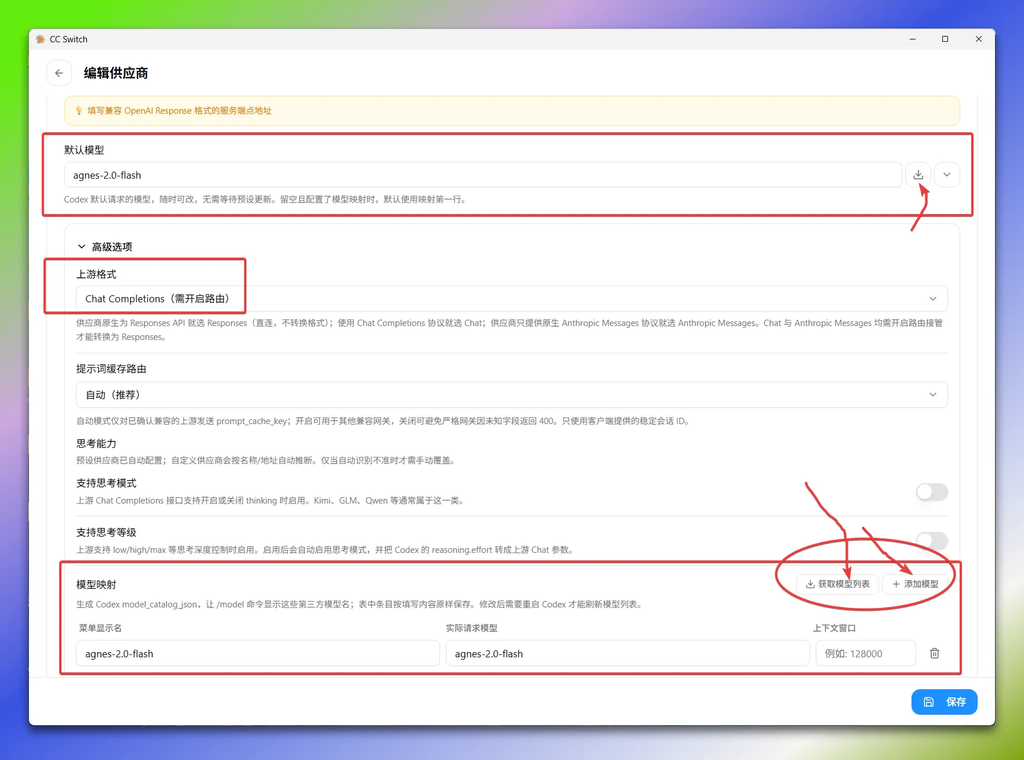

##### codex++

[figure not shown]

### 三.常见问题

#### 无法显示agnes-2.0-flash

CC switch 当中配置了 API，但是 codex 当中显示的模型列表依然是 GPT 官方模型列表？

解决办法：

将下面的这个文件夹全部删除，重新启动。

```
%USERPROFILE%\.codex
```

#### 输出报404错误

[figure not shown]

问题的根因

**两个协议的区别**

|  | **Responses API** | **Chat Completions API** |
| --- | --- | --- |
| **端点** | `/v1/responses` | `/v1/chat/completions` |
| **谁在用** | OpenAI 官方 Codex、最新版 ChatGPT | 绝大多数第三方 AI（Agnes、DeepSeek、Claude 等） |
| **功能** | 支持工具调用、文件操作、多轮状态保持 | 基础对话，一问一答 |
| **兼容性** | 只有 OpenAI 原生支持 | 行业通用标准 |

CC Switch 的作用就是**翻译官**：

```
 Codex 客户端 ──/v1/responses──→ CC Switch ──【翻译成 /v1/chat/completions】──→ Agnes AI
```

所以需要在 CC Switch 里打开**本地路由映射**，让它自动把 Responses 请求转成 Chat Completions 请求，再发给 Agnes AI。

Agnes AI 只懂 `/v1/chat/completions`，不懂 `/v1/responses`，所以报 404。

```
Codex 客户端 ──请求 /v1/responses──→ CC Switch ──转发 /v1/responses──→ Agnes AI
                                                                         ↑
                                                                    不认识这个端点
                                                                    返回 404
```

- `model_provider`：决定 Codex 把模型请求发送到哪里；
- 模型网关：在 Codex 和模型服务之间完成协议转换、鉴权、路由、日志或限流

|  | model_provider | 模型网关 (CC Switch) |
| --- | --- | --- |
| **是什么** | 上游服务商 | 本地代理/路由器 |
| **职责** | 提供模型推理能力 | 接收客户端请求，决定发给谁 |
| **位置** | 远端（云端） | 本地（你的电脑 `127.0.0.1:15721`） |
| **数量** | 可以配置多个 | 只有一个（就是 CC Switch） |
| **协议转换** | 不做 | **核心功能**：Responses ↔︎ Chat Completions |

发送下面的提示词给其他的智能体，帮你修复。

```
我在CC Switch配置Agnes AI 可以，上游协议选择Chat Completions，启动codex对话报错
```

### 参考资料

ChatGPT 中文教程 https://www.codex-docs.com/docs

大模型API报错信息分析工具 https://errs.dmxapi.cn/